# sta141a project

Christie Ngo

11/28/2021

```r
insurance = read.csv("C:/Users/chris/Documents/STA 141A/insurance.csv")
insurance$smoker_status = ifelse(insurance$smoker == "Yes", 1, 0)
# insignificant: sex

insurance$smoker_status = ifelse(insurance$smoker == "yes", 1, 0)
insurance$southwest = ifelse(insurance$region == "southwest", 1, 0)
insurance$southeast = ifelse(insurance$region == "southeast", 1, 0)
insurance$northwest = ifelse(insurance$region == "northwest", 1, 0)
insurance$northeast = ifelse(insurance$region == "northeast", 1, 0) # collinear

model = lm(charges~smoker_status+sex+bmi+children+age+southwest+southeast+northwest, data=insurance)
summary(model)
```

```
##
## Call:
## lm(formula = charges ~ smoker_status + sex + bmi + children +
##     age + southwest + southeast + northwest, data = insurance)
##
## Residuals:
##      Min       1Q   Median       3Q      Max
## -11304.9  -2848.1   -982.1   1393.9  29992.8
##
## Coefficients:
##               Estimate Std. Error t value Pr(>|t|)
## (Intercept)   -11938.5      987.8 -12.086  < 2e-16 ***
## smoker_status  23848.5      413.1  57.723  < 2e-16 ***
## sexmale         -131.3      332.9  -0.394 0.693348
## bmi              339.2       28.6  11.860  < 2e-16 ***
## children         475.5      137.8   3.451 0.000577 ***
## age              256.9       11.9  21.587  < 2e-16 ***
## southwest       -960.0      477.9  -2.009 0.044765 *
## southeast      -1035.0      478.7  -2.162 0.030782 *
## northwest       -353.0      476.3  -0.741 0.458769
## ---
## Signif. codes:  0 '***' 0.001 '**' 0.01 '*' 0.05 '.' 0.1 ' ' 1
##
## Residual standard error: 6062 on 1329 degrees of freedom
## Multiple R-squared:  0.7509, Adjusted R-squared:  0.7494
## F-statistic: 500.8 on 8 and 1329 DF,  p-value: < 2.2e-16
```

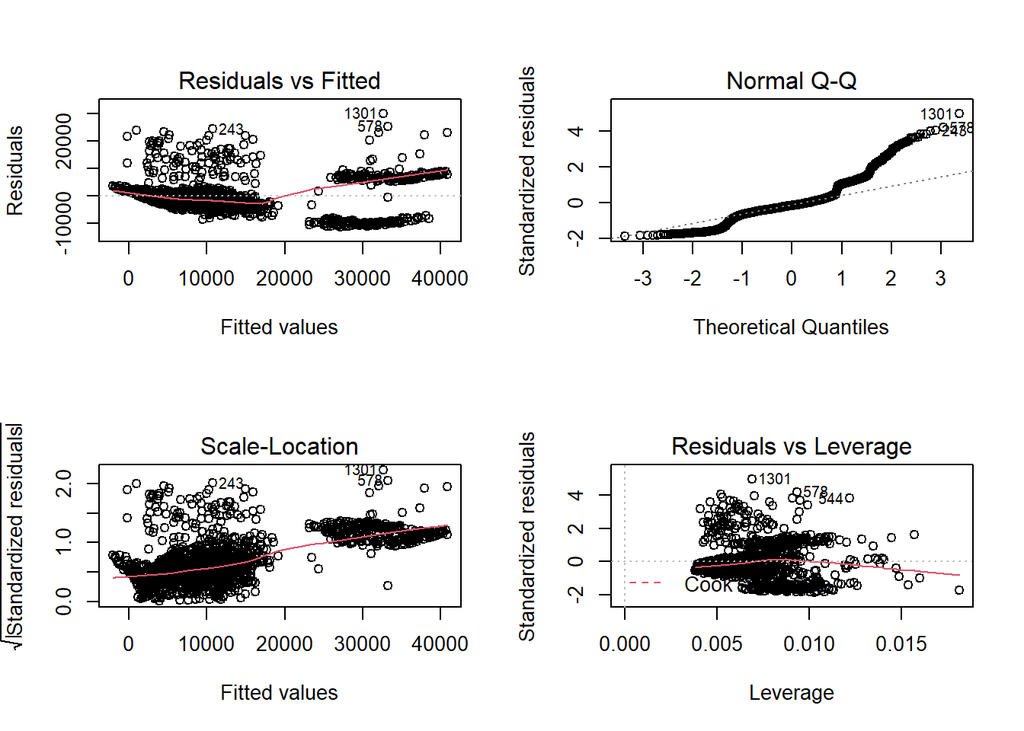

```r
par(mfrow=c(2,2))
plot(model)
```

We are removing sex as a predictor variable from the overall data because the t-value of -0.394 is not significant. The p-value is 0.6933. Overall the current model explains 74.94% of the variance in charges with a residual standard error of 6062. From the plots, we can see that the quantile-quantile plot is not linear and the residuals vs. fitted values plot shows two distinct groups. We will try to subset the dataset for nonsmokers and smokers.

```r
# for overall dataset
outliers = rstandard(model)[rstandard(model) < -3 | rstandard(model) > 3]
indices = as.numeric(names(outliers))
leverages = hatvalues(model)
select = leverages[indices]
```

```r
select[leverages[indices] > ((11+1)/1388)]
```

```
##         544         578         820        1013        1231
## 0.012173584 0.009354004 0.009098803 0.009910240 0.009496975
```

These points are the outliers (outside of 3 standard deviations) that are also leverage points. These points will be removed from the data set after we subset based on smoker status.

```r
nonsmoker = insurance[insurance$smoker_status == 0,]
smoker = insurance[insurance$smoker_status == 1,]

nonsmoker_fit = lm(charges~bmi+children+age+southeast+southwest+northwest, data=nonsmoker)
outliers_ns = rstandard(nonsmoker_fit)[rstandard(nonsmoker_fit) < -3 | rstandard(nonsmoker_fit) > 3]
indices_ns = as.numeric(names(outliers_ns))
leverages_ns = hatvalues(nonsmoker_fit)
select_ns = leverages_ns[indices_ns]
high_leverage = select_ns[leverages_ns[indices_ns] > ((4+1)/1064)]

nonsmoker_clean = nonsmoker[!seq_len(nrow(nonsmoker)) %in% na.omit(as.numeric(names(high_leverage))),]
nonsmoker_fit2 = lm(charges~bmi+children+age+southeast+southwest+northwest, data=nonsmoker_clean)

summary(nonsmoker_fit2)
```

```
##
## Call:
## lm(formula = charges ~ bmi + children + age + southeast + southwest +
##     northwest, data = nonsmoker_clean)
##
## Residuals:
##     Min      1Q  Median      3Q     Max
## -2848.1 -1875.4 -1361.8  -697.5 24619.5
##
## Coefficients:
##             Estimate Std. Error t value Pr(>|t|)
## (Intercept) -2455.38     849.52  -2.890  0.00393 **
## bmi            16.99      25.09   0.677  0.49848
## children      595.40     117.76   5.056 5.06e-07 ***
## age           265.04      10.30  25.721  < 2e-16 ***
## southeast    -935.68     421.29  -2.221  0.02657 *
## southwest   -1340.74     409.88  -3.271  0.00111 **
## northwest    -479.95     409.83  -1.171  0.24183
## ---
## Signif. codes:  0 '***' 0.001 '**' 0.01 '*' 0.05 '.' 0.1 ' ' 1
##
## Residual standard error: 4635 on 1032 degrees of freedom
## Multiple R-squared:  0.4112, Adjusted R-squared:  0.4078
## F-statistic: 120.1 on 6 and 1032 DF,  p-value: < 2.2e-16
```

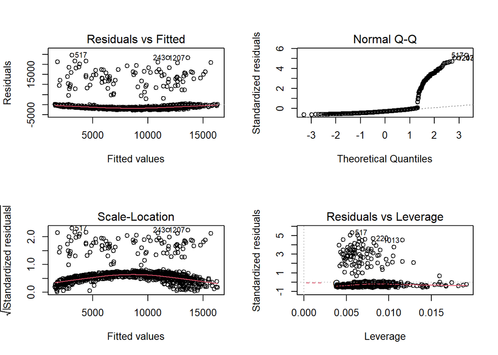

```r
par(mfrow = c(2,2))
plot(nonsmoker_fit2)
```

```r
nonsmoker_log = lm(log(charges)~children+age+southeast+southwest+northwest, data=nonsmoker_clean) # R^2 0.6812

nonsmoker_squareroot = lm(sqrt(charges)~children+age+southeast+southwest+northwest, data=nonsmoker_clean) # R^2 0.569

nonsmoker_inverse = lm((1/charges)~children+age+southeast+southwest+northwest, data=nonsmoker_clean)# R^2 0.6596

# choose LOG transformation
```

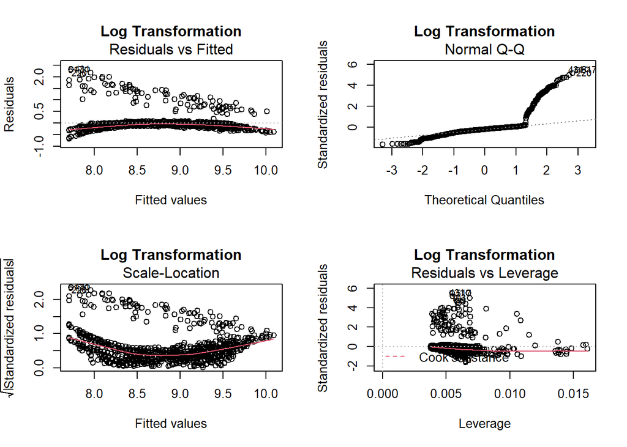

```r
par(mfrow=c(2,2))
plot(nonsmoker_log, main = "Log Transformation")
```

The quantile-quantile plot curves towards the end and the residual plots are not random. This model explains 68.12% of variance in charges.

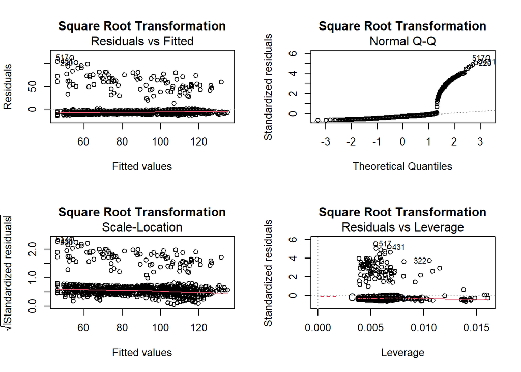

```r
par(mfrow=c(2,2))
plot(nonsmoker_squareroot, main = "Square Root Transformation")
```

This quantile-quantile plot shoes the most curvature and the residuals still show a pattern. This model only explains 56.90% of the variance in charges.

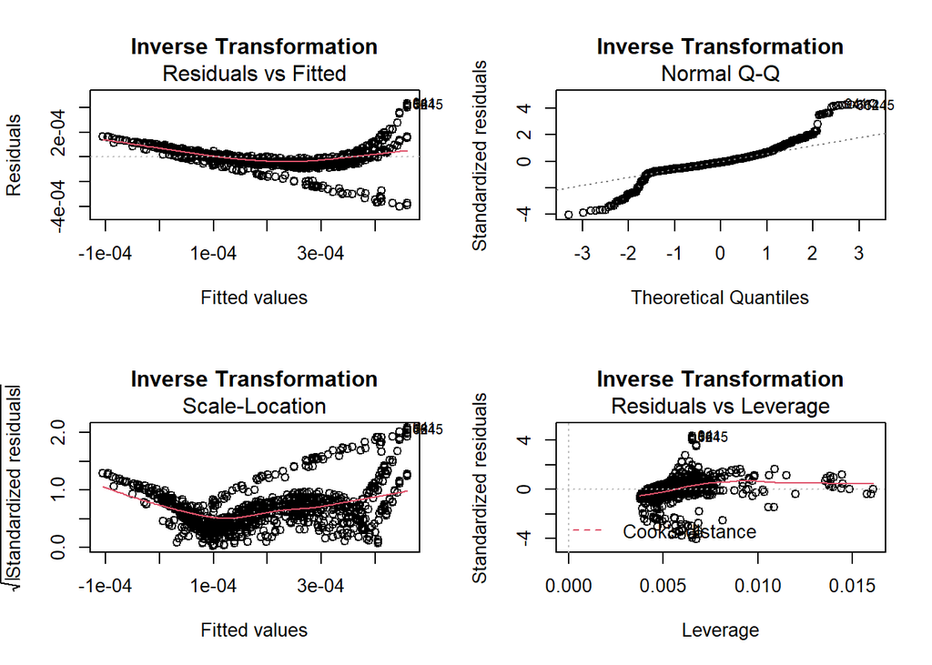

```r
par(mfrow=c(2,2))
plot(nonsmoker_inverse, main = "Inverse Transformation")
```

This quantile-quantile plot now shoes curvature on both tails and the residuals show a distinct curved pattern.